# Análise do Censo SUAS - CRAS

19 de outubro de 2018

## Objeto (tema central da apresentação)

O Censo SUAS é uma pesquisa realizada todos os anos para coletar informações a respeito da situação dos equipamentos de Assistência Social no Brasil. Entre os equipamentos encontram-se os Centros de Referência de Assistência Social, os CRAS.

## Objetivos (questões de pesquisa que o trabalho irá responder)

A primeira pergunta é sobre a situação do imóvel onde se localiza o CRAS.

A segunda pergunta é sobre o compartilhamento de espaços entre o CRAS e outra unidade administrativa

## Contexto (justificativa)

A política de Assistência Social é realizada de forma triparticípe, sendo importante o reconhecimento da população da existência do espaço do CRAS. Disto a importância de existir, se possível a independencia do CRAS das demais estruturas administrativas.

## - Método (como foram coletados, tratados e organizados os dados)

O arquivo que foi usado foi recuperado do link “https://aplicacoes.mds.gov.br/snas/vigilancia/index2.php”, mantido pelo MDS. Este arquivo tem as respostas no ano de 2017 dos 8.292 CRAS que responderam a pesquisa, na primeira aba. Na segunda aba tem um dicionário de variáveis usadas para criar o data frame dicionario.

A primeira análise será a situação do imóveis, na qual próprio é a situação mais desejada

## Situação do imóvel onde se localiza o CRAS

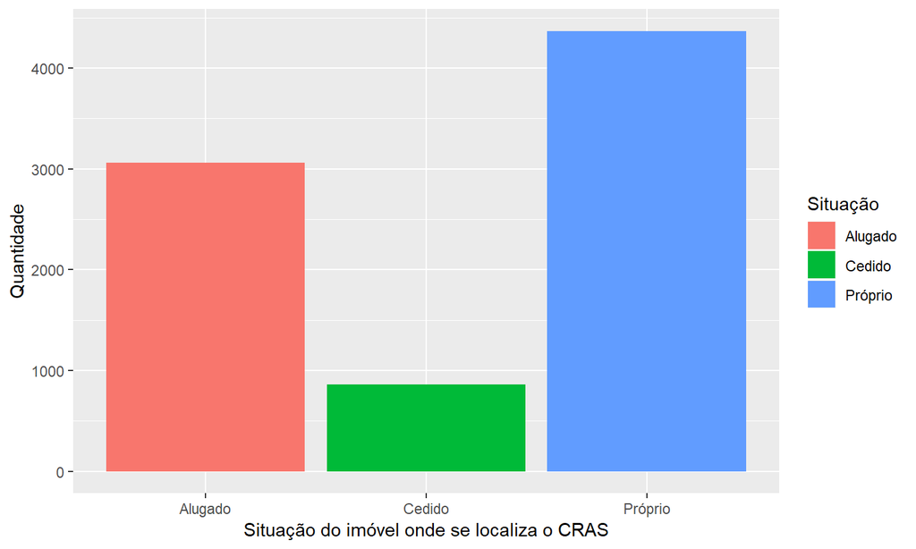

## Compartilhada espaços

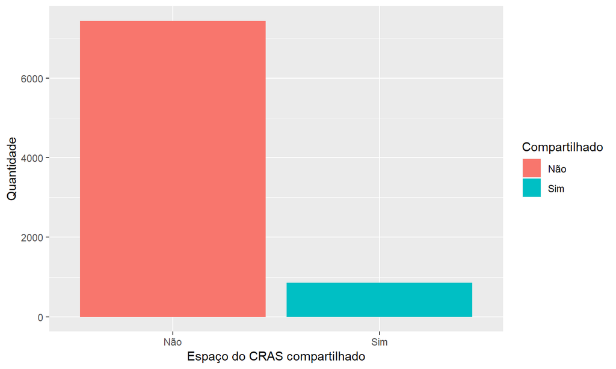

## Espaços compartilhados

```
## # A tibble: 205 x 13
## # Groups:   q7.1, q7.2, q7.3, q7.4, q7.5, q7.6, q7.7, q7.8, q7.9, q7.10,
## #   q7.11, q7.12 [205]
##    q7.1  q7.2  q7.3  q7.4  q7.5  q7.6  q7.7  q7.8  q7.9  q7.10 q7.11 q7.12
##    <chr> <chr> <chr> <chr> <chr> <chr> <chr> <chr> <chr> <chr> <chr> <chr>
##  1 Não   Não   Não   Não   Não   Não   Não   Não   Não   Não   Não   Sim
##  2 Não   Não   Não   Não   Não   Não   Não   Não   Não   Não   Sim   Não
##  3 Não   Não   Não   Não   Não   Não   Não   Não   Não   Não   Sim   Sim
##  4 Não   Não   Não   Não   Não   Não   Não   Não   Não   Sim   Não   Não
##  5 Não   Não   Não   Não   Não   Não   Não   Não   Não   Sim   Sim   Não
##  6 Não   Não   Não   Não   Não   Não   Não   Não   Não   Sim   Sim   Sim
##  7 Não   Não   Não   Não   Não   Não   Não   Não   Sim   Não   Não   Não
##  8 Não   Não   Não   Não   Não   Não   Não   Não   Sim   Sim   Não   Não
##  9 Não   Não   Não   Não   Não   Não   Não   Sim   Não   Não   Não   Não
## 10 Não   Não   Não   Não   Não   Não   Não   Sim   Não   Sim   Sim   Não
## # ... with 195 more rows, and 1 more variable: n <int>
```